# Coursera Data Science Machine Learning Project

John Beal

Sunday, July 26, 2015

## Introduction

Machine learning procedures were applied to a data set relating to how well a set of exercises were performed by a group of 6 participants. Accelerometer data from the belt, forearm, arm and dumbbell were recorded as the participants performed one set of 10 repetitions of a unilateral dumbbell bicep curl, using either correct technique or one of four deliberately incorrect techniques. Exploratory data analysis was performed to aid in feature selection, before a series of models were trained on the data using appropriate cross-validation methodology to estimate the out-of-sample error. Classification and Regression Tree and Random Forest models were fit, but the accuracy of the Random Forest model was judged to be superior. The final model produced by the Random Forest process was used to predict the outcomes of 20 cases from a reserved test data set.

## Data Collection

The data used in this project originate from the Weight Lifting Exercise Dataset from the Human Activity Recognition (HAR) project website from [`Groupware@LES`](http://groupware.les.inf.puc-rio.br/har). The data were already partitioned into a training and a test set, which were read into data frames from their respective csv files.

```r
training <- read.csv(".//Data//pml-training.csv")
testing <- read.csv(".//Data//pml-testing.csv")
```

## Method

The caret package (V.6.0-52) was used for model training and prediction. The rattle package was used to graph dendrigrams, and the polytomous package was used to calculate accuracy from contingency tables.

```r
library(caret)
library(rattle)
library(polytomous)
```

## Exploratory Data Analysis & Feature Selection

The training data set contains 19622 observations of 160 variables, including the outcome variable ‘classe’. The occurrence of various variable classes was examined with a contingency table. There were initially 37 variables classified as factors, however after inspecting a list of these variables, it appeared that the majority had been misidentified by read.csv. These variables were converted to the numeric type.

```r
table(sapply(training, class))                                                          ## Contingency table of variable class.
```

```
##
##  factor integer numeric
##      37      35      88
```

```r
allfactornames <- names(sapply(training, class)[sapply(training, class)=="factor"])     ## Names of all factor variables.
print(allfactornames)
```

```
##  [1] "user_name"               "cvtd_timestamp"
##  [3] "new_window"              "kurtosis_roll_belt"
##  [5] "kurtosis_picth_belt"     "kurtosis_yaw_belt"
##  [7] "skewness_roll_belt"      "skewness_roll_belt.1"
##  [9] "skewness_yaw_belt"       "max_yaw_belt"
## [11] "min_yaw_belt"            "amplitude_yaw_belt"
## [13] "kurtosis_roll_arm"       "kurtosis_picth_arm"
## [15] "kurtosis_yaw_arm"        "skewness_roll_arm"
## [17] "skewness_pitch_arm"      "skewness_yaw_arm"
## [19] "kurtosis_roll_dumbbell"  "kurtosis_picth_dumbbell"
## [21] "kurtosis_yaw_dumbbell"   "skewness_roll_dumbbell"
## [23] "skewness_pitch_dumbbell" "skewness_yaw_dumbbell"
## [25] "max_yaw_dumbbell"        "min_yaw_dumbbell"
## [27] "amplitude_yaw_dumbbell"  "kurtosis_roll_forearm"
## [29] "kurtosis_picth_forearm"  "kurtosis_yaw_forearm"
## [31] "skewness_roll_forearm"   "skewness_pitch_forearm"
## [33] "skewness_yaw_forearm"    "max_yaw_forearm"
## [35] "min_yaw_forearm"         "amplitude_yaw_forearm"
## [37] "classe"
```

```r
keepAsFactor <- c("user_name", "cvtd_timestamp", "new_window", "classe")                ## Variables to remain as factors.
changeAsFactor <- allfactornames[!allfactornames %in% keepAsFactor]                     ## Variables to convert to numeric.
for (i in seq_along(training)) {                                                        ## Loop through and convert to numeric.
        if (names(training)[i] %in% changeAsFactor) {
                training[, i] <- as.numeric(levels(training[ , i]))[as.integer(training[, i])]
        }
}
```

```r
NAprop <- numeric(length = length(training))                                            ## Initialise vector & assign names
names(NAprop) <- names(training)                                                        ## from training set.
for (i in seq_along(training)) {
        NAprop[i] <- round((sum(is.na(training[, i]))/length(training[, i])), 3)}       ## Determine proportion of NA values.
table(NAprop)                                                                           ## Contingency table of NA proportions.
```

```
## NAprop
##     0 0.979  0.98 0.981 0.983 0.984     1
##    60    69    12     2     4     7     6
```

```r
training2 <- training[, (names(NAprop[NAprop==0]))]                                     ## Subset on variables with no NAs.
```

Of the remaining variables, 7 were “book keeping” variables, containing information on the row number, name of participant, time stamp data and data relating to the recording window. These variables will not serve as meaningful predictors, as they do not contain generalisable information, and as such were excluded from the data set.

```r
training3 <- subset(training2, select = -c(1:7))        ## Remove first 7 columns pertaining to book keeping data
```

## Prediction Function Selection

In order to reduce the computational requirements while developing a model, the training data set was sub-sampled by partitioning, to create a smaller data set for model training and selection; while the remainder was retained to validate the preferred model before its final application to the test set.

```r
inTrain <- createDataPartition(y = training3$classe, p = 0.33, list = FALSE)    ##Subsample across the classe variable to make
training_part <- training3[inTrain, ]                                           ##smaller set for model training.
testing_part <- training3[-inTrain, ]                                           ## Retain rest for model validation
```

### Classification and Regression Tree

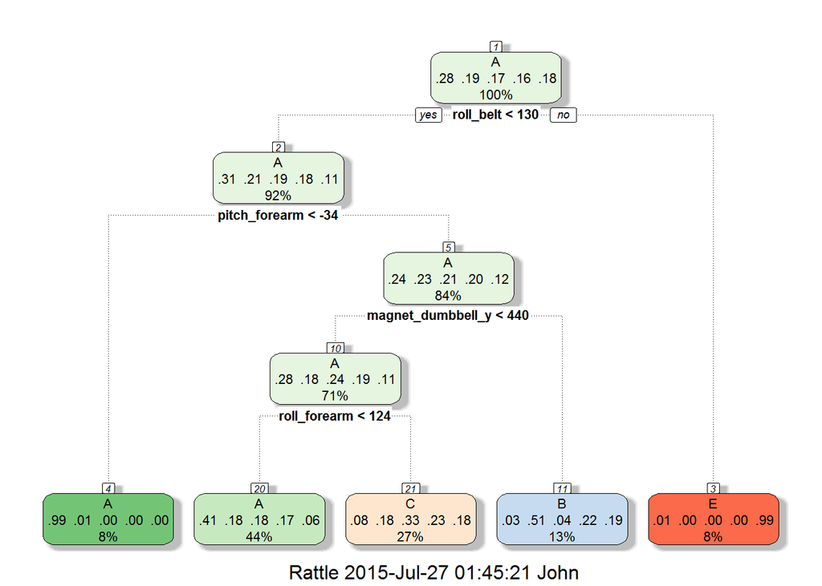

```r
set.seed(65784)
train_control <- trainControl(method = "cv", number = 10)                       ## Set k-folds cross validation with k = 10
modFit <- train(classe ~ ., method = "rpart", data = training3,
                trControl = train_control)                                      ## Train using rpart
fancyRpartPlot(modFit$finalModel)
```

```r
modFit$results
```

```
##           cp  Accuracy      Kappa AccuracySD    KappaSD
## 1 0.03567868 0.5085645 0.35827095 0.01506924 0.02005923
## 2 0.05998671 0.4275130 0.22839234 0.06277141 0.10673601
## 3 0.11515454 0.3398677 0.08453363 0.03827331 0.05837393
```

### Random Forest

```r
set.seed(87942)
train_control <- trainControl(method = "cv", number = 5)                        ## Set k-folds cross validation with k = 5
modFit2 <- train(classe ~ ., method = "rf", data = training_part,
                 prox = TRUE, allowParallel = TRUE)                             ## Train using rf (Random Forest) method
modFit2                                                                         ## Random Forest output
```

```
## Random Forest
##
## 6479 samples
##   52 predictor
##    5 classes: 'A', 'B', 'C', 'D', 'E'
##
## No pre-processing
## Resampling: Bootstrapped (25 reps)
## Summary of sample sizes: 6479, 6479, 6479, 6479, 6479, 6479, ...
## Resampling results across tuning parameters:
##
##   mtry  Accuracy   Kappa      Accuracy SD  Kappa SD
##    2    0.9736769  0.9666815  0.003089834  0.003919038
##   27    0.9760854  0.9697355  0.003102240  0.003925952
##   52    0.9693183  0.9611715  0.005916310  0.007480494
##
## Accuracy was used to select the optimal model using  the largest value.
## The final value used for the model was mtry = 27.
```

```r
modFit2$finalModel                                                              ## Final model
```

```
##
## Call:
##  randomForest(x = x, y = y, mtry = param$mtry, proximity = TRUE,      allowParallel = TRUE)
##                Type of random forest: classification
##                      Number of trees: 500
## No. of variables tried at each split: 27
##
##         OOB estimate of  error rate: 1.56%
## Confusion matrix:
##      A    B    C    D    E class.error
## A 1837    5    0    0    0 0.002714441
## B   22 1221    9    1    1 0.026315789
## C    0   14 1107    9    0 0.020353982
## D    0    1   21 1037    3 0.023540490
## E    2    2    4    7 1176 0.012594458
```

```r
varImp(modFit2)                                                                 ## Variable importance for model
```

```
## rf variable importance
##
##   only 20 most important variables shown (out of 52)
##
##                      Overall
## roll_belt             100.00
## pitch_forearm          65.44
## yaw_belt               50.26
## magnet_dumbbell_z      43.35
## magnet_dumbbell_y      41.43
## pitch_belt             41.17
## roll_forearm           36.47
## accel_dumbbell_y       20.04
## roll_dumbbell          17.78
## magnet_dumbbell_x      16.39
## accel_forearm_x        15.70
## magnet_belt_z          15.46
## magnet_forearm_z       14.72
## accel_belt_z           14.07
## accel_dumbbell_z       13.24
## gyros_belt_z           12.93
## magnet_belt_y          12.16
## total_accel_dumbbell   11.56
## magnet_belt_x          11.50
## yaw_arm                11.19
```

## Validation of Model

Before preceding to validate the model on the test set, the final model from the Random Forest approach was tested on the remaining data from the training set, which the model had NOT been trained on. As can be seen in the following contingency table, the model prediction was excellent.

```r
pred <- predict(modFit2, newdata = testing_part)                        ##Predict for reserved training data using final model
testing_part$predRight <- pred==testing_part$classe                     ## Judge success of predictions
table(pred, testing_part$classe)                                        ## Contingency table of predictions
```

```
##
## pred    A    B    C    D    E
##    A 3724   34    0    0    0
##    B    9 2488   17    1    4
##    C    4   18 2264   43    4
##    D    0    1   11 2103    8
##    E    1    2    0    7 2400
```

```r
crosstable.statistics(table(pred, testing_part$classe))$accuracy        ## Accuracy of predictions
```

```
## [1] 0.9875219
```

An accuracy of 0.988 was calculated, which suggests an estimated out-of-sample error rate of <2%.

## Prediction of Test Set Outcomes

The model was then used to predict the outcome of the 20 cases contained in the test set.

```r
testpred <- predict(modFit2, newdata = testing)
testpred
```

```
##  [1] B A B A A E D B A A B C B A E E A B B B
## Levels: A B C D E
```